# HW07 Data Importing and Wrangling

Dylan Klingeman

19 July 2020

```r
library(tidyverse)
library(here)
```

### Limpets

```r
limpets_data <- read_csv(here("data", "limpets.csv"))
```

This chunk imports the data from the limpets.csv file.

# Check if the data is tidy

The limpets data is tidy and arranged in 3 neat columns.

```r
limpets_data <- read_csv(here("data", "limpets.csv"),col_types = "ncc")
```

Assigns the column types to numerical, character, character

# Assign order factor

```r
factor(limpets_data$Site, levels = c("PBL", "KNRM", "VBG", "WP", "PF", "DP", "SIO", "CTZ1", "CTZ2", "CNM"), ordered = TRUE)
```

[output not shown]

[output cut: 22 more lines]

# Boxplot of limpets data

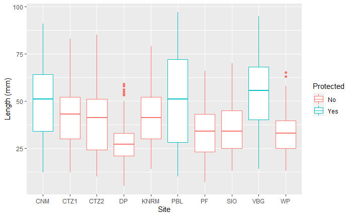

```r
ggplot(data=limpets_data) +
  geom_boxplot(mapping = aes(x = Site, y = Length, color = Protected)) +
  labs(x = "Site", y = "Length (mm)")
```

There are outliers for two of the sites which are the WP and DP sites. We can see the dots outside of the “whisker” of the boxplot. Its also worth noting that these two are both unprotected sites. Looking at the data the protected sites all have the longest length of limpets.

### Roseate Terms

```r
roseate_data <- read_tsv(here("data", "roseate_terns.txt"))
```

Loads the roseate_terns data set.

# Check if the data is tidy

The data set is not tidy and separated into many differant columns

```r
tidy_roseate <- roseate_data %>%
  pivot_longer(c(AR:JC),
                names_to = "Site",
                values_to = "Population")
```

Tidies the data so that the variables in the columns were categorized into “Site” and population".

```r
tidy_roseate
```

| year | Site | Population |
| --- | --- | --- |
| 1992 | AR | 378 |
| 1992 | AL | 76 |
| 1992 | AC | 29 |
| 1992 | BR | 378 |
| 1992 | BL | NA |
| 1992 | BC | 29 |
| 1992 | JR | 651 |
| 1992 | JL | NA |
| 1992 | JC | 35 |
| 1993 | AR | 427 |

[output cut: 215 more lines]

# Filter out missing terms

```r
filter(drop_na(tidy_roseate))
```

| year | Site | Population |
| --- | --- | --- |
| 1992 | AR | 378 |
| 1992 | AL | 76 |
| 1992 | AC | 29 |
| 1992 | BR | 378 |
| 1992 | BC | 29 |
| 1992 | JR | 651 |
| 1992 | JC | 35 |
| 1993 | AR | 427 |
| 1993 | AL | 76 |
| 1993 | AC | 28 |

[output cut: 204 more lines]

Removes incomplete terms from the data set.

# Line plot of roseate data

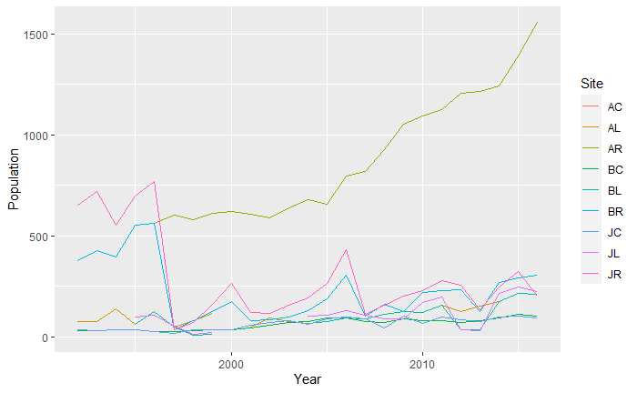

```r
ggplot(data = tidy_roseate) +
  geom_line(mapping = aes(x = year, y = Population, color = Site)) +
  labs(x = "Year")
```

Creates a lineplot for the roseate terns data set. Year is applied to the x variable and population to the y variable. The site where the measurements were taken is then applied to color. A label is applied to “year” so that it is capitalized in the graph.

Significant increase: AR,BC Significant decrease: BR, JR

There were some other changes that fluctuated over the years, but these were the most stark changes to me.

# Chunk 1: Boxplot

```r
abalone_data <- read_csv(here("data", "abalone.csv"))
select(abalone_data, -(X1))
```

| Type | LongestShell | Diameter | Height | WholeWeight | ShuckedWeight | VisceraWeight | ShellWeight | Rings |
| --- | --- | --- | --- | --- | --- | --- | --- | --- |
| M | 0.455 | 0.365 | 0.095 | 0.5140 | 0.2245 | 0.1010 | 0.1500 | 15 |
| M | 0.350 | 0.265 | 0.090 | 0.2255 | 0.0995 | 0.0485 | 0.0700 | 7 |
| F | 0.530 | 0.420 | 0.135 | 0.6770 | 0.2565 | 0.1415 | 0.2100 | 9 |
| M | 0.440 | 0.365 | 0.125 | 0.5160 | 0.2155 | 0.1140 | 0.1550 | 10 |
| I | 0.330 | 0.255 | 0.080 | 0.2050 | 0.0895 | 0.0395 | 0.0550 | 7 |
| I | 0.425 | 0.300 | 0.095 | 0.3515 | 0.1410 | 0.0775 | 0.1200 | 8 |
| F | 0.530 | 0.415 | 0.150 | 0.7775 | 0.2370 | 0.1415 | 0.3300 | 20 |
| F | 0.545 | 0.425 | 0.125 | 0.7680 | 0.2940 | 0.1495 | 0.2600 | 16 |
| M | 0.475 | 0.370 | 0.125 | 0.5095 | 0.2165 | 0.1125 | 0.1650 | 9 |
| F | 0.550 | 0.440 | 0.150 | 0.8945 | 0.3145 | 0.1510 | 0.3200 | 19 |

[output cut: 990 more lines]

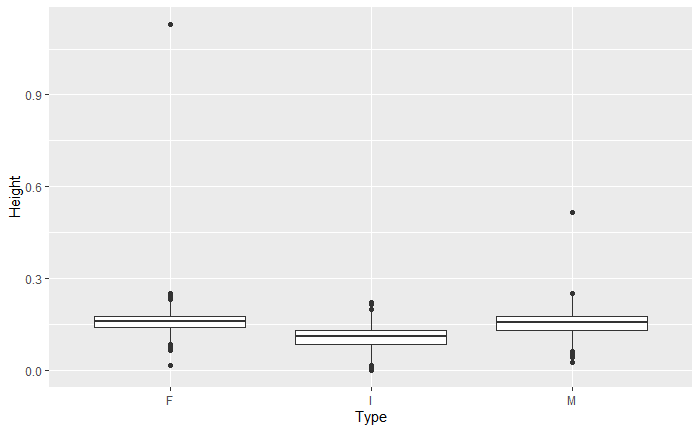

```r
ggplot(data  = abalone_data) +
  geom_boxplot(mapping = aes(x = Type, y = Height))
```

This code chunk: imports the abalone data set, removes it’s first column, and then graphs it into a boxplot comapring height and type. Removing the column is done by the -(X1)) argument.

# Chunk 2: Scatterplot

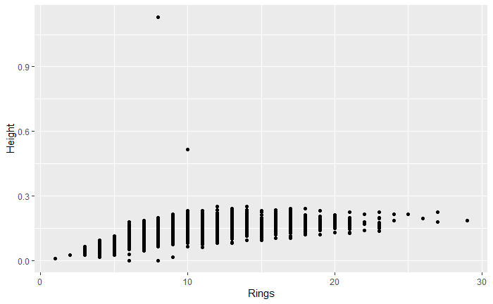

```r
ggplot(data = abalone_data) +
  geom_point(mapping = aes(x = Rings, y = Height))
```

The two outliers are not particularly old trees, as we can see by their ring count. They are in fact young.

# Chunk 3: Filter and recreate scatterplot

```r
abalone_data_filtered <- filter(abalone_data, Height <= 0.35)
factor(abalone_data_filtered$Type, levels = c("I", "M", "F"))
```

[output not shown]

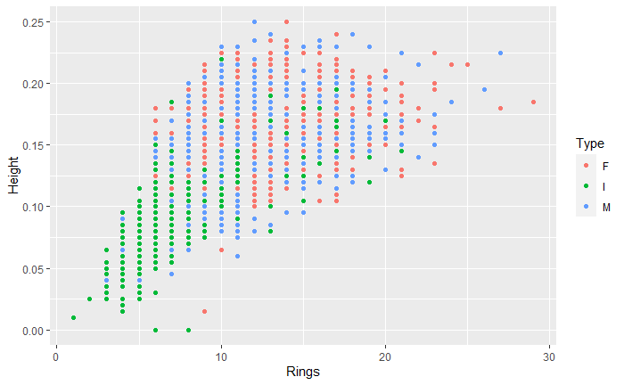

```r
ggplot(data = abalone_data_filtered) +
  geom_point(mapping = aes(x = Rings, y = Height, color = Type))
```

# Chunk 4: Assinging NA

```r
na_if(abalone_data_filtered$Height, 0)
```

[output not shown]

[output cut: 39 more lines]

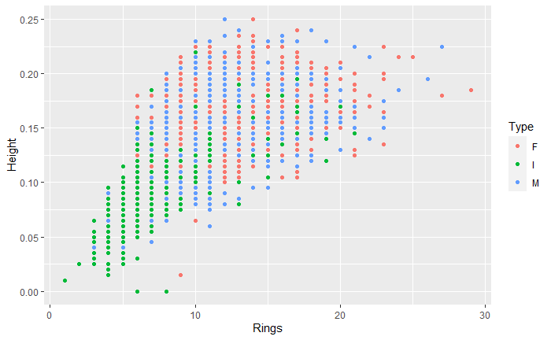

```r
ggplot(data = abalone_data_filtered) +
  geom_point(mapping = aes(x = Rings, y = Height, color = Type))
```

# Chunk 5: Two scatterplots

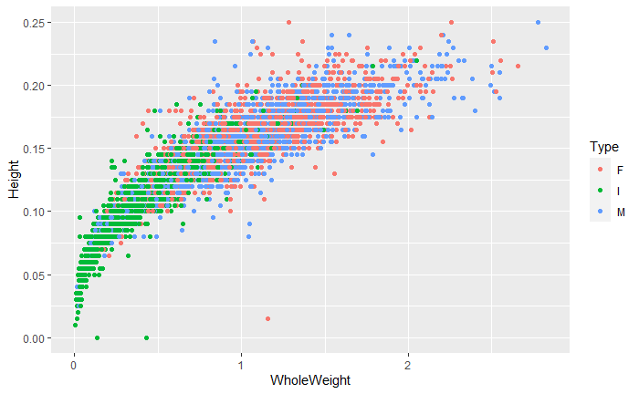

```r
ggplot(data = abalone_data_filtered) +
  geom_point(mapping = aes(x = WholeWeight, y = Height, color = Type))
```

This code chunk creates a scatterplot comparing the whole weight of a tree to its height, as well as the type. From this graph we can see that the weight is the lowest on immature trees, as one would expect, and even though female trees tend to be taller, males tend to have a heigher whole weight.

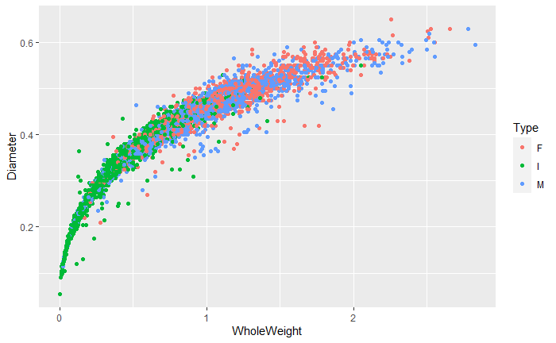

```r
ggplot(data = abalone_data_filtered) +
  geom_point(mapping = aes(x = WholeWeight, y = Diameter, color = Type))
```

This code chunk creates a scatterplot comparing the whole weight of a tree to its diamater, as wella s displaying the type of the tree. This graph appears visually very much like the above one, as trees with a higher diameter tend to have a higher whole weight. This follows what we would expect, also of note is that the male and female trees seem evenly dispersed in diameter.

### Darters

```r
darters_data <- read_fwf(here("data", "darter.txt"), fwf_widths(c(3, 11, 1, 1, 1, 3, 4, 4, 4, 3, 3, 2, 2)), comment = '#')
named_darter <- darters_data %>%
  rename(ID = X1, Species = X2, Riffle = X3, Age = X4, Sex = X5, Length = X6, Depth = X7, Velocity = X8, Temperature = X9, Major_Sub = X10, Minor_Sub = X11, Major_Type = X12, Minor_Type = X13)
```

This code chunk organizes the data. The width of each column is specified by the number given. These are taken from the ranges given in the .txt document. Names are then assigned to each of the columns

```r
named_darter$Riffle <- factor(named_darter$Riffle,levels=c('1','2'))
named_darter$Major_Type <- factor(named_darter$Major_Type, levels = c("s", "fg", "sg", "lg", "c"), ordered = TRUE)
```

This code chunk applies factors to the Riffle and Major_type categories. An ordered factor is appleid to the major types, and an order is assigned. For the Riffle an unordered factor is applied.

```r
named_darter %>%
  filter(Species=="blennioides" | Species == "caeruleum" | Species == "spectabile") %>%
  rename(Major_Substrate = Major_Sub, Major_Type = Major_Type)
 arrange(named_darter, ID)
 select(named_darter, -(c(Minor_Type, Minor_Sub)))
```

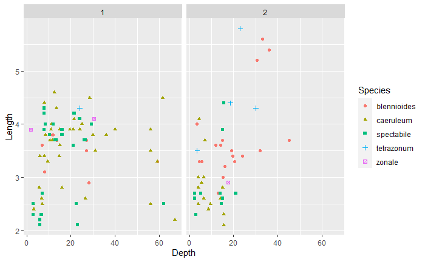

```r
ggplot(data = named_darter) +
  geom_point(mapping = aes(x = Depth, y = Length, color = Species, shape = Species)) +
  facet_wrap(~Riffle, nrow =  1)
```

This code chunk creates a scatterplot for the darter data set. The depth is being compared to the length, with the species being separated by both color and shape.

When comparing the two riffles the first difference I noticed was in the Blennioides. Blennioides are much more prevalent in the 2nd ripple and are shown to have a significant length difference. Another trend we can see is the depth is much higher on the first riffle. There are no species past 50 in the 2nd riffle, but there is botha recorded spectabile and caeruleum past 60 in the first riffle.

# Plot 2

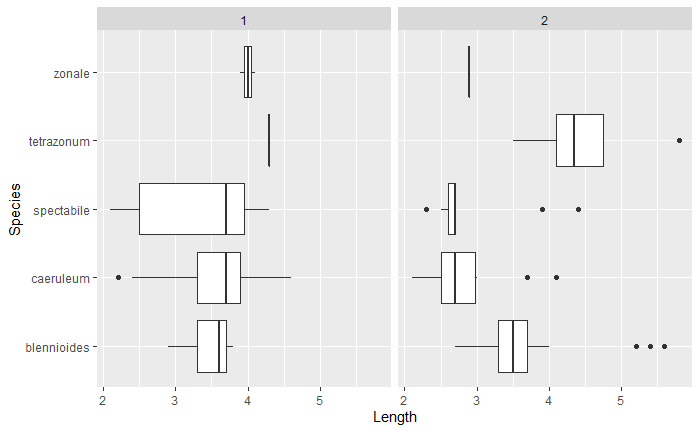

```r
ggplot(data = named_darter) +
  geom_boxplot(mapping = aes(x = Species, y = Length)) +
  facet_wrap(~Riffle, nrow = 1) +
  coord_flip()
```

This code chunk creates a boxplot for the darter data set. The length of each species is compared between two riffles. A facet_wrap is applied to separate out these two riffles, and then a coord_flip is applied to improve visuals of the graph.

The second riffle has significantly more outliers than the first riffle.

# Plot 3

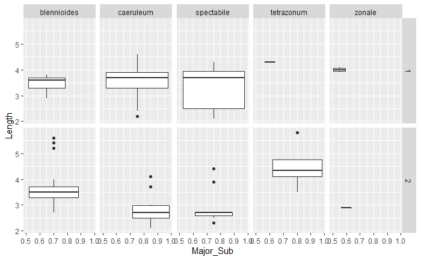

```r
ggplot(data = named_darter) +
  geom_boxplot(mapping = aes(x = Major_Sub, y = Length)) +
  facet_grid(Riffle ~ Species)
```

```r
ggplot(data = named_darter) +
  geom_boxplot(mapping = aes(x = Major_Sub, y = Length)) +
  facet_grid(Species ~ Riffle)
```

[output not shown]

The word listed first in the facet_grid is what will be on the y axis. For this case, it is much more clear visually if Species is placed on the y axis.